# AQLI_Test

## World AQI Analysis

### Import Libraries

```python
import pandas as pd
import geopandas as gpd
import numpy as np
import matplotlib.pyplot as plt
import seaborn as sns
```

```python
import warnings
warnings.simplefilter('ignore')
```

### Read Data

```python
world = gpd.read_file("gadm2_aqli_shapefile/aqli_gadm2_final_june302023.shp")
world.head()
```

|  | obidgadm2 | name0 | name1 | name2 | geometry |
| --- | --- | --- | --- | --- | --- |
| 0 | 1 | Afghanistan | Badakhshan | Baharak | POLYGON ((71.41149 36.55717, 71.40954 36.55237... |
| 1 | 2 | Afghanistan | Badakhshan | Darwaz | POLYGON ((71.27620 38.00465, 71.27578 38.00471... |
| 2 | 3 | Afghanistan | Badakhshan | Fayzabad | POLYGON ((70.78272 37.27678, 70.78635 37.27388... |
| 3 | 4 | Afghanistan | Badakhshan | Ishkashim | POLYGON ((71.41149 36.55717, 71.40091 36.56163... |
| 4 | 5 | Afghanistan | Badakhshan | Jurm | POLYGON ((70.71236 37.07621, 70.73582 37.06548... |

```python
world_countries = world.dissolve(by='name0')
world_countries
```

| name0 | geometry | obidgadm2 | name1 | name2 |
| --- | --- | --- | --- | --- |
| Afghanistan | MULTIPOLYGON (((63.61554 29.46970, 63.61425 29... | 1 | Badakhshan | Baharak |
| Akrotiri and Dhekelia | MULTIPOLYGON (((33.00867 34.63230, 33.00764 34... | 329 | Akrotiri | None |
| Albania | MULTIPOLYGON (((19.84179 40.04882, 19.83501 40... | 344 | Berat | Beratit |
| Algeria | MULTIPOLYGON (((1.32778 20.73215, 1.31754 20.7... | 381 | Adrar | Adrar |
| American Samoa | MULTIPOLYGON (((-170.76183 -14.36973, -170.762... | 1885 | Eastern | Ituau |
| ... | ... | ... | ... | ... |
| Western Sahara | MULTIPOLYGON (((-16.83569 22.15403, -16.83597 ... | 47671 | Boujdour | None |
| Yemen | MULTIPOLYGON (((42.57319 13.44986, 42.57319 13... | 47675 | `Adan | Al Buraiqeh |
| Zambia | POLYGON ((25.87834 -17.97218, 25.87034 -17.970... | 48007 | Central | Chibombo |
| Zimbabwe | POLYGON ((28.38668 -21.61435, 28.38649 -21.614... | 48122 | Bulawayo | Bulawayo |
| Åland | MULTIPOLYGON (((19.95361 59.83820, 19.95417 59... | 331 | Archipelago | Föglö |

252 rows × 4 columns

#### Visualize shapefile at gadm 2 level

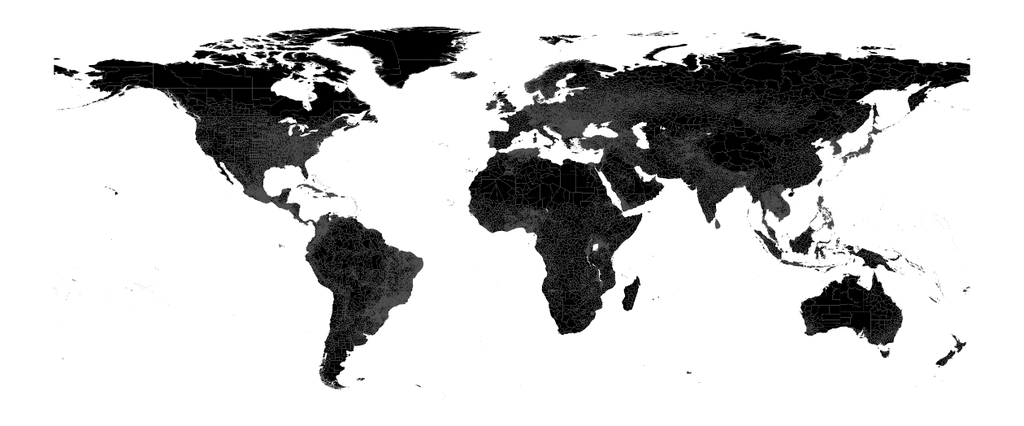

```python
fig, ax = plt.subplots(1, figsize =(16, 8))
ax.axis('off')
world.plot(ax = ax, color ='black')
```

#### Visualize shapefile at country level

For computational efficiency

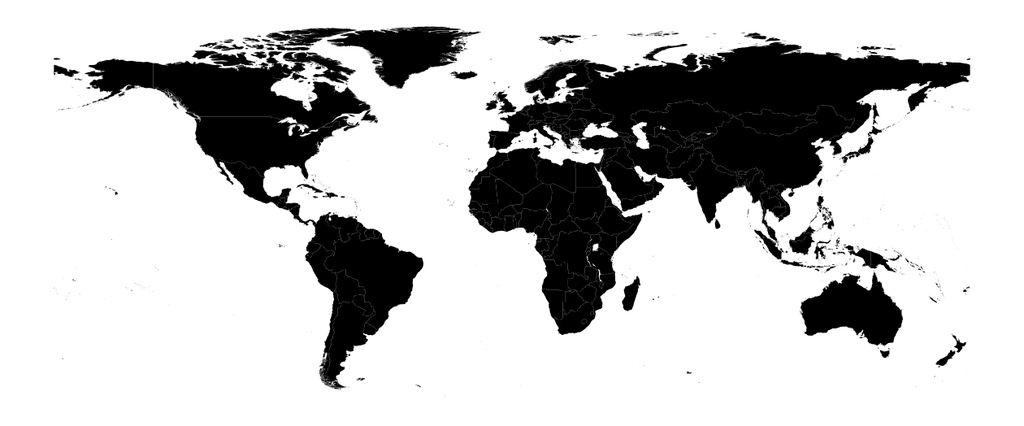

```python
fig, ax = plt.subplots(1, figsize =(16, 8))
ax.axis('off')
world_countries.plot(ax = ax, color ='black')
```

```python
world.name0.unique()
```

```
array(['Afghanistan', 'Akrotiri and Dhekelia', 'Åland', 'Albania',
       'Algeria', 'American Samoa', 'Andorra', 'Angola', 'Anguilla',
       'Antigua and Barbuda', 'Argentina', 'Armenia', 'Aruba',
       'Australia', 'Austria', 'Azerbaijan', 'Bahamas', 'Bahrain',
       'Bangladesh', 'Barbados', 'Belarus', 'Belgium', 'Belize', 'Benin',
       'Bermuda', 'Bhutan', 'Bolivia', 'Bonaire, Sint Eustatius and Saba',
       'Bosnia and Herzegovina', 'Botswana', 'Bouvet Island', 'Brazil',
       'British Indian Ocean Territory', 'British Virgin Islands',
       'Brunei', 'Bulgaria', 'Burkina Faso', 'Burundi', 'Cabo Verde',
       'Cambodia', 'Cameroon', 'Canada', 'Cayman Islands',
       'Central African Republic', 'Chad', 'Chile', 'China',
       'Christmas Island', 'Clipperton Island', 'Cocos Islands',
       'Colombia', 'Comoros', 'Cook Islands', 'Costa Rica',
       "Côte d'Ivoire", 'Croatia', 'Cuba', 'Curaçao', 'Cyprus', 'Czechia',
       'Democratic Republic of the Congo', 'Denmark', 'Djibouti',
       'Dominica', 'Dominican Republic', 'Ecuador', 'Egypt',
       'El Salvador', 'Equatorial Guinea', 'Eritrea', 'Estonia',
       'Ethiopia', 'Falkland Islands', 'Faroe Islands', 'Fiji', 'Finland',
       'France', 'French Guiana', 'French Polynesia',
       'French Southern Territories', 'Gabon', 'Gambia', 'Georgia',
       'Germany', 'Ghana', 'Gibraltar', 'Greece', 'Greenland', 'Grenada',
       'Guadeloupe', 'Guam', 'Guatemala', 'Guernsey', 'Guinea',
       'Guinea-Bissau', 'Guyana', 'Haiti',
       'Heard Island and McDonald Island', 'Honduras', 'Hungary',
       'Iceland', 'India', 'Indonesia', 'Iran', 'Iraq', 'Ireland',
       'Isle of Man', 'Israel', 'Italy', 'Jamaica', 'Japan', 'Jersey',
       'Jordan', 'Kazakhstan', 'Kenya', 'Kiribati', 'Kosovo', 'Kuwait',
       'Kyrgyzstan', 'Laos', 'Latvia', 'Lebanon', 'Lesotho', 'Liberia',
       'Libya', 'Liechtenstein', 'Lithuania', 'Luxembourg', 'Madagascar',
       'Malawi', 'Malaysia', 'Maldives', 'Mali', 'Malta',
       'Marshall Islands', 'Martinique', 'Mauritania', 'Mauritius',
       'Mayotte', 'México', 'Micronesia', 'Moldova', 'Monaco', 'Mongolia',
       'Montenegro', 'Montserrat', 'Morocco', 'Mozambique', 'Myanmar',
       'Namibia', 'Nauru', 'Nepal', 'Netherlands', 'New Caledonia',
       'New Zealand', 'Nicaragua', 'Niger', 'Nigeria', 'Niue',
       'Norfolk Island', 'North Korea', 'Macedonia', 'Northern Cyprus',
       'Northern Mariana Islands', 'Norway', 'Oman', 'Pakistan', 'Palau',
       'Palestine', 'Panama', 'Papua New Guinea', 'Paracel Islands',
       'Paraguay', 'Peru', 'Philippines', 'Pitcairn Islands', 'Poland',
       'Portugal', 'Puerto Rico', 'Qatar', 'Republic of the Congo',
       'Réunion', 'Romania', 'Russia', 'Rwanda', 'Saint-Barthélemy',
       'Saint-Martin', 'Saint Helena, Ascension and Tris',
       'Saint Kitts and Nevis', 'Saint Lucia',
       'Saint Pierre and Miquelon', 'Saint Vincent and the Grenadines',
       'Samoa', 'San Marino', 'São Tomé and Príncipe', 'Saudi Arabia',
       'Senegal', 'Serbia', 'Seychelles', 'Sierra Leone', 'Singapore',
       'Sint Maarten', 'Slovakia', 'Slovenia', 'Solomon Islands',
       'Somalia', 'South Africa', 'South Georgia and the South Sand',
       'South Korea', 'South Sudan', 'Spain', 'Spratly Islands',
       'Sri Lanka', 'Sudan', 'Suriname', 'Svalbard and Jan Mayen',
       'Swaziland', 'Sweden', 'Switzerland', 'Syria', 'Taiwan',
       'Tajikistan', 'Tanzania', 'Thailand', 'Timor-Leste', 'Togo',
       'Tokelau', 'Tonga', 'Trinidad and Tobago', 'Tunisia', 'Turkey',
       'Turkmenistan', 'Turks and Caicos Islands', 'Tuvalu', 'Uganda',
       'Ukraine', 'United Arab Emirates', 'United Kingdom',
       'United States', 'United States Minor Outlying Islands', 'Uruguay',
       'Uzbekistan', 'Vanuatu', 'Vatican City', 'Venezuela', 'Vietnam',
       'Virgin Islands, U.S.', 'Wallis and Futuna', 'Western Sahara',
       'Yemen', 'Zambia', 'Zimbabwe'], dtype=object)
```

### 1. Basic wrangling tasks and questions

```python
ind_gadm = world[world.name0 == 'India']
ind_gadm
```

|  | obidgadm2 | name0 | name1 | name2 | geometry |
| --- | --- | --- | --- | --- | --- |
| 17295 | 17298 | India | Andaman and Nicobar | Nicobar Islands | MULTIPOLYGON (((93.78988 6.85201, 93.79015 6.8... |
| 17296 | 17299 | India | Andaman and Nicobar | North and Middle Andaman | MULTIPOLYGON (((92.84441 12.14969, 92.84466 12... |
| 17297 | 17300 | India | Andaman and Nicobar | South Andaman | MULTIPOLYGON (((92.52111 10.89694, 92.52306 10... |
| 17298 | 17301 | India | Andhra Pradesh | Anantapur | POLYGON ((77.84600 13.92832, 77.83012 13.92715... |
| 17299 | 17302 | India | Andhra Pradesh | Chittoor | POLYGON ((78.54555 12.74391, 78.55031 12.73876... |
| ... | ... | ... | ... | ... | ... |
| 17980 | 17983 | India | West Bengal | Pashchim Medinipur | POLYGON ((86.72535 22.21350, 86.73376 22.21122... |
| 17981 | 17984 | India | West Bengal | Purba Medinipur | MULTIPOLYGON (((87.48176 21.60946, 87.48171 21... |
| 17982 | 17985 | India | West Bengal | Puruliya | POLYGON ((85.87758 23.47586, 85.89125 23.47598... |
| 17983 | 17986 | India | West Bengal | South 24 Parganas | MULTIPOLYGON (((88.02139 21.57111, 88.02111 21... |
| 17984 | 17987 | India | West Bengal | Uttar Dinajpur | MULTIPOLYGON (((88.45433 25.66300, 88.45429 25... |

690 rows × 5 columns

#### 1.1 How many GADM2 regions are present in India?

```python
len(ind_gadm)
```

```
690
```

```python
world.columns
```

```
Index(['obidgadm2', 'name0', 'name1', 'name2', 'geometry'], dtype='object')
```

```python
data = pd.read_csv(r'gadm2_aqli_1998_2021.csv')
data.head()
```

|  | objectid_gadm2 | iso_alpha3 | country | name_1 | name_2 | population | whostandard | natstandard | pm1998 | pm1999 | ... | llpp_nat_2012 | llpp_nat_2013 | llpp_nat_2014 | llpp_nat_2015 | llpp_nat_2016 | llpp_nat_2017 | llpp_nat_2018 | llpp_nat_2019 | llpp_nat_2020 | llpp_nat_2021 |
| --- | --- | --- | --- | --- | --- | --- | --- | --- | --- | --- | --- | --- | --- | --- | --- | --- | --- | --- | --- | --- | --- |
| 0 | 1 | AFG | Afghanistan | Badakhshan | Baharak | 95535.0 | 5 | 35.0 | 8.29 | 9.31 | ... | 0.0 | 0.0 | 0.0 | 0.0 | 0.0 | 0.0 | 0.0 | 0.0 | 0.0 | 0.0 |
| 1 | 2 | AFG | Afghanistan | Badakhshan | Darwaz | 27665.0 | 5 | 35.0 | 8.19 | 8.14 | ... | 0.0 | 0.0 | 0.0 | 0.0 | 0.0 | 0.0 | 0.0 | 0.0 | 0.0 | 0.0 |
| 2 | 3 | AFG | Afghanistan | Badakhshan | Fayzabad | 302299.0 | 5 | 35.0 | 7.83 | 8.58 | ... | 0.0 | 0.0 | 0.0 | 0.0 | 0.0 | 0.0 | 0.0 | 0.0 | 0.0 | 0.0 |
| 3 | 4 | AFG | Afghanistan | Badakhshan | Ishkashim | 18326.0 | 5 | 35.0 | 8.20 | 9.58 | ... | 0.0 | 0.0 | 0.0 | 0.0 | 0.0 | 0.0 | 0.0 | 0.0 | 0.0 | 0.0 |
| 4 | 5 | AFG | Afghanistan | Badakhshan | Jurm | 94396.0 | 5 | 35.0 | 8.28 | 9.25 | ... | 0.0 | 0.0 | 0.0 | 0.0 | 0.0 | 0.0 | 0.0 | 0.0 | 0.0 | 0.0 |

5 rows × 80 columns

```python
data.columns
```

```
Index(['objectid_gadm2', 'iso_alpha3', 'country', 'name_1', 'name_2',
       'population', 'whostandard', 'natstandard', 'pm1998', 'pm1999',
       'pm2000', 'pm2001', 'pm2002', 'pm2003', 'pm2004', 'pm2005', 'pm2006',
       'pm2007', 'pm2008', 'pm2009', 'pm2010', 'pm2011', 'pm2012', 'pm2013',
       'pm2014', 'pm2015', 'pm2016', 'pm2017', 'pm2018', 'pm2019', 'pm2020',
       'pm2021', 'llpp_who_1998', 'llpp_who_1999', 'llpp_who_2000',
       'llpp_who_2001', 'llpp_who_2002', 'llpp_who_2003', 'llpp_who_2004',
       'llpp_who_2005', 'llpp_who_2006', 'llpp_who_2007', 'llpp_who_2008',
       'llpp_who_2009', 'llpp_who_2010', 'llpp_who_2011', 'llpp_who_2012',
       'llpp_who_2013', 'llpp_who_2014', 'llpp_who_2015', 'llpp_who_2016',
       'llpp_who_2017', 'llpp_who_2018', 'llpp_who_2019', 'llpp_who_2020',
       'llpp_who_2021', 'llpp_nat_1998', 'llpp_nat_1999', 'llpp_nat_2000',
       'llpp_nat_2001', 'llpp_nat_2002', 'llpp_nat_2003', 'llpp_nat_2004',
       'llpp_nat_2005', 'llpp_nat_2006', 'llpp_nat_2007', 'llpp_nat_2008',
       'llpp_nat_2009', 'llpp_nat_2010', 'llpp_nat_2011', 'llpp_nat_2012',
       'llpp_nat_2013', 'llpp_nat_2014', 'llpp_nat_2015', 'llpp_nat_2016',
       'llpp_nat_2017', 'llpp_nat_2018', 'llpp_nat_2019', 'llpp_nat_2020',
       'llpp_nat_2021'],
      dtype='object')
```

```python
cols_pm = []
for cols in data.columns:
    if 'pm' in cols or 'pp' in cols:
        cols_pm.append(cols)
# print (cols_pm)
country_df = data.groupby('country')[cols_pm].mean()
country_df
```

| country | pm1998 | pm1999 | pm2000 | pm2001 | pm2002 | pm2003 | pm2004 | pm2005 | pm2006 | pm2007 | ... | llpp_nat_2012 | llpp_nat_2013 | llpp_nat_2014 | llpp_nat_2015 | llpp_nat_2016 | llpp_nat_2017 | llpp_nat_2018 | llpp_nat_2019 | llpp_nat_2020 | llpp_nat_2021 |
| --- | --- | --- | --- | --- | --- | --- | --- | --- | --- | --- | --- | --- | --- | --- | --- | --- | --- | --- | --- | --- | --- |
| Afghanistan | 11.248537 | 11.091098 | 12.235030 | 14.414421 | 14.022287 | 14.296860 | 13.011372 | 14.478384 | 15.003018 | 14.327500 | ... | 0.000000 | 0.000000 | 0.0 | 0.000640 | 0.000518 | 0.0 | 0.0 | 0.001921 | 0.00689 | 0.005976 |
| Akrotiri and Dhekelia | 11.580000 | 11.515000 | 13.825000 | 12.780000 | 11.060000 | 11.535000 | 10.825000 | 12.025000 | 11.975000 | 12.200000 | ... | NaN | NaN | NaN | NaN | NaN | NaN | NaN | NaN | NaN | NaN |
| Albania | 16.865405 | 15.637297 | 17.362703 | 16.527027 | 18.489189 | 20.197568 | 15.982432 | 17.530811 | 19.736216 | 18.438378 | ... | 0.031892 | 0.001351 | 0.0 | 0.013514 | 0.000000 | 0.0 | 0.0 | 0.000000 | 0.00000 | 0.000000 |
| Algeria | 6.059541 | 5.463989 | 5.864375 | 5.940199 | 5.941509 | 7.432633 | 5.375279 | 6.820259 | 6.813165 | 6.579468 | ... | NaN | NaN | NaN | NaN | NaN | NaN | NaN | NaN | NaN | NaN |
| American Samoa | 0.767500 | 0.925625 | 1.181250 | 1.099375 | 1.250000 | 1.295625 | 1.022500 | 1.501250 | 1.310625 | 1.314375 | ... | NaN | NaN | NaN | NaN | NaN | NaN | NaN | NaN | NaN | NaN |
| ... | ... | ... | ... | ... | ... | ... | ... | ... | ... | ... | ... | ... | ... | ... | ... | ... | ... | ... | ... | ... | ... |
| Western Sahara | 4.582500 | 5.750000 | 4.360000 | 4.482500 | 4.762500 | 4.357500 | 4.010000 | 4.300000 | 4.082500 | 4.547500 | ... | NaN | NaN | NaN | NaN | NaN | NaN | NaN | NaN | NaN | NaN |
| Yemen | 11.563313 | 13.563464 | 14.020361 | 11.879548 | 13.575452 | 13.191898 | 12.776717 | 12.955572 | 14.851536 | 15.324789 | ... | NaN | NaN | NaN | NaN | NaN | NaN | NaN | NaN | NaN | NaN |
| Zambia | 17.196348 | 14.752348 | 18.079043 | 24.901478 | 22.857826 | 22.445826 | 20.656522 | 22.935043 | 20.845826 | 23.899391 | ... | NaN | NaN | NaN | NaN | NaN | NaN | NaN | NaN | NaN | NaN |
| Zimbabwe | 16.930659 | 13.591099 | 13.906813 | 20.771648 | 16.723407 | 18.088132 | 15.827363 | 18.250330 | 16.390989 | 18.872308 | ... | NaN | NaN | NaN | NaN | NaN | NaN | NaN | NaN | NaN | NaN |
| Åland | 6.787692 | 7.214615 | 6.036154 | 5.401538 | 5.851538 | 5.899231 | 6.063077 | 6.334615 | 7.236154 | 5.692308 | ... | NaN | NaN | NaN | NaN | NaN | NaN | NaN | NaN | NaN | NaN |

252 rows × 72 columns

#### Save the country level file as a CSV.

```python
country_df.to_csv('countrylevel_pwa.csv')
```

#### What are the 10 most polluted countries in 2021?

```python
country_df.sort_values('pm2021', ascending = False)[0:10]
```

| country | pm1998 | pm1999 | pm2000 | pm2001 | pm2002 | pm2003 | pm2004 | pm2005 | pm2006 | pm2007 | ... | llpp_nat_2012 | llpp_nat_2013 | llpp_nat_2014 | llpp_nat_2015 | llpp_nat_2016 | llpp_nat_2017 | llpp_nat_2018 | llpp_nat_2019 | llpp_nat_2020 | llpp_nat_2021 |
| --- | --- | --- | --- | --- | --- | --- | --- | --- | --- | --- | --- | --- | --- | --- | --- | --- | --- | --- | --- | --- | --- |
| Bangladesh | 44.083125 | 44.000312 | 49.817813 | 51.911563 | 51.779688 | 53.256094 | 52.465625 | 57.311875 | 62.168750 | 60.342188 | ... | 5.275313 | 4.823594 | 5.095625 | 4.723906 | 4.811250 | 4.566094 | 5.741875 | 4.904219 | 5.734375 | 5.566875 |
| India | 30.334652 | 30.502710 | 32.868304 | 36.501319 | 36.527899 | 39.422072 | 39.048739 | 39.906435 | 41.685681 | 43.127855 | ... | 1.067899 | 1.227304 | 1.069551 | 1.122580 | 1.303725 | 1.140580 | 1.180348 | 1.380290 | 1.376159 | 1.530623 |
| Nepal | 24.448052 | 24.535195 | 32.276494 | 36.745325 | 33.107143 | 34.086883 | 35.448182 | 33.704416 | 38.301818 | 38.746753 | ... | NaN | NaN | NaN | NaN | NaN | NaN | NaN | NaN | NaN | NaN |
| Pakistan | 24.331625 | 23.781438 | 25.478750 | 27.188625 | 26.620313 | 27.414750 | 27.219187 | 29.156375 | 32.175000 | 31.572500 | ... | 1.655500 | 1.721750 | 1.688687 | 2.038062 | 1.996563 | 1.760625 | 1.582062 | 1.905438 | 2.001937 | 1.960750 |
| Myanmar | 26.341125 | 27.511875 | 24.532000 | 26.858000 | 27.247125 | 28.075625 | 31.757250 | 30.648000 | 30.914000 | 33.297250 | ... | NaN | NaN | NaN | NaN | NaN | NaN | NaN | NaN | NaN | NaN |
| Democratic Republic of the Congo | 34.923556 | 26.530921 | 32.704226 | 35.017573 | 35.283808 | 33.491674 | 35.772803 | 35.488870 | 30.281506 | 33.694812 | ... | NaN | NaN | NaN | NaN | NaN | NaN | NaN | NaN | NaN | NaN |
| Cameroon | 34.438103 | 32.103966 | 33.578793 | 35.502414 | 33.200517 | 33.261034 | 34.206207 | 34.191034 | 31.455345 | 32.511379 | ... | NaN | NaN | NaN | NaN | NaN | NaN | NaN | NaN | NaN | NaN |
| Republic of the Congo | 28.645417 | 23.747708 | 28.291250 | 30.624583 | 30.034583 | 27.815625 | 32.071875 | 29.095625 | 25.635000 | 29.727917 | ... | NaN | NaN | NaN | NaN | NaN | NaN | NaN | NaN | NaN | NaN |
| Rwanda | 29.110000 | 21.861000 | 33.366000 | 38.171000 | 34.406000 | 27.953667 | 35.669333 | 35.301333 | 30.361333 | 39.526667 | ... | NaN | NaN | NaN | NaN | NaN | NaN | NaN | NaN | NaN | NaN |
| Burundi | 27.682180 | 20.484135 | 31.578421 | 37.170602 | 33.276391 | 29.621955 | 35.255188 | 34.953985 | 29.870075 | 38.826992 | ... | NaN | NaN | NaN | NaN | NaN | NaN | NaN | NaN | NaN | NaN |

10 rows × 72 columns

#### 1.3 What was the most polluted GADM2 region in the world in 1998, 2005 and 2021?

```python
data1998 = data.sort_values('pm1998', ascending = False)[:1]
data1998['name_2']
```

```
17950    Unnao
Name: name_2, dtype: object
```

```python
data2005 = data.sort_values('pm2005', ascending = False)[:1]
data2005['name_2']
```

```
17710    NCT of Delhi
Name: name_2, dtype: object
```

```python
data2021 = data.sort_values('pm2021', ascending = False)[:1]
data2021['name_2']
```

```
17710    NCT of Delhi
Name: name_2, dtype: object
```

```python
ind_up = data[data['name_1'] == 'Uttar Pradesh'].groupby('name_1')[cols_pm].mean()
ind_up
```

| name_1 | pm1998 | pm1999 | pm2000 | pm2001 | pm2002 | pm2003 | pm2004 | pm2005 | pm2006 | pm2007 | ... | llpp_nat_2012 | llpp_nat_2013 | llpp_nat_2014 | llpp_nat_2015 | llpp_nat_2016 | llpp_nat_2017 | llpp_nat_2018 | llpp_nat_2019 | llpp_nat_2020 | llpp_nat_2021 |
| --- | --- | --- | --- | --- | --- | --- | --- | --- | --- | --- | --- | --- | --- | --- | --- | --- | --- | --- | --- | --- | --- |
| Uttar Pradesh | 60.395333 | 57.428933 | 63.3332 | 69.44 | 69.900933 | 77.578133 | 75.368533 | 74.6736 | 73.345067 | 78.067733 | ... | 4.0316 | 4.5112 | 3.824 | 4.050533 | 4.927733 | 4.429333 | 4.334933 | 5.0732 | 4.668667 | 5.203867 |

1 rows × 72 columns

[figure not shown]

```python
first_row = ind_up.iloc[0]

# Apply seaborn style
sns.set_style("whitegrid")

first_row.plot(title="Uttar Pradesh PM2.5 (1998 - 2021)", kind='line', marker='o', figsize=(10, 6), markersize=6, linewidth=2, color='red')
plt.xlabel('Year', fontsize=12)
plt.ylabel('PM2.5 Concentration', fontsize=12)
plt.xticks(rotation=45, fontsize=10)
plt.yticks(fontsize=10)

plt.title("Uttar Pradesh PM2.5 (1998 - 2021)", fontsize=14, fontweight='bold')

plt.grid(True, linestyle='--', alpha=0.4)

plt.savefig("Uttar_Pradesh_PM25.png", dpi=300, bbox_inches='tight')
```

### 2. Geospatial tasks and questions

#### 2.1 Plot a bar graph for the life years lost relative to the WHO guideline in the 10 most polluted countries in the world and also plot them on a global country level map. For the map, the 10 most polluted country boundaries should be filled in with “dark red” and the rest of the map should be grayed out. Save both the bar graph and the map as high quality PNG files.

```python
most_polluted2021 = country_df.sort_values('pm2021', ascending = False)[0:10]
most_polluted2021
```

| country | pm1998 | pm1999 | pm2000 | pm2001 | pm2002 | pm2003 | pm2004 | pm2005 | pm2006 | pm2007 | ... | llpp_nat_2012 | llpp_nat_2013 | llpp_nat_2014 | llpp_nat_2015 | llpp_nat_2016 | llpp_nat_2017 | llpp_nat_2018 | llpp_nat_2019 | llpp_nat_2020 | llpp_nat_2021 |
| --- | --- | --- | --- | --- | --- | --- | --- | --- | --- | --- | --- | --- | --- | --- | --- | --- | --- | --- | --- | --- | --- |
| Bangladesh | 44.083125 | 44.000312 | 49.817813 | 51.911563 | 51.779688 | 53.256094 | 52.465625 | 57.311875 | 62.168750 | 60.342188 | ... | 5.275313 | 4.823594 | 5.095625 | 4.723906 | 4.811250 | 4.566094 | 5.741875 | 4.904219 | 5.734375 | 5.566875 |
| India | 30.334652 | 30.502710 | 32.868304 | 36.501319 | 36.527899 | 39.422072 | 39.048739 | 39.906435 | 41.685681 | 43.127855 | ... | 1.067899 | 1.227304 | 1.069551 | 1.122580 | 1.303725 | 1.140580 | 1.180348 | 1.380290 | 1.376159 | 1.530623 |
| Nepal | 24.448052 | 24.535195 | 32.276494 | 36.745325 | 33.107143 | 34.086883 | 35.448182 | 33.704416 | 38.301818 | 38.746753 | ... | NaN | NaN | NaN | NaN | NaN | NaN | NaN | NaN | NaN | NaN |
| Pakistan | 24.331625 | 23.781438 | 25.478750 | 27.188625 | 26.620313 | 27.414750 | 27.219187 | 29.156375 | 32.175000 | 31.572500 | ... | 1.655500 | 1.721750 | 1.688687 | 2.038062 | 1.996563 | 1.760625 | 1.582062 | 1.905438 | 2.001937 | 1.960750 |
| Myanmar | 26.341125 | 27.511875 | 24.532000 | 26.858000 | 27.247125 | 28.075625 | 31.757250 | 30.648000 | 30.914000 | 33.297250 | ... | NaN | NaN | NaN | NaN | NaN | NaN | NaN | NaN | NaN | NaN |
| Democratic Republic of the Congo | 34.923556 | 26.530921 | 32.704226 | 35.017573 | 35.283808 | 33.491674 | 35.772803 | 35.488870 | 30.281506 | 33.694812 | ... | NaN | NaN | NaN | NaN | NaN | NaN | NaN | NaN | NaN | NaN |
| Cameroon | 34.438103 | 32.103966 | 33.578793 | 35.502414 | 33.200517 | 33.261034 | 34.206207 | 34.191034 | 31.455345 | 32.511379 | ... | NaN | NaN | NaN | NaN | NaN | NaN | NaN | NaN | NaN | NaN |
| Republic of the Congo | 28.645417 | 23.747708 | 28.291250 | 30.624583 | 30.034583 | 27.815625 | 32.071875 | 29.095625 | 25.635000 | 29.727917 | ... | NaN | NaN | NaN | NaN | NaN | NaN | NaN | NaN | NaN | NaN |
| Rwanda | 29.110000 | 21.861000 | 33.366000 | 38.171000 | 34.406000 | 27.953667 | 35.669333 | 35.301333 | 30.361333 | 39.526667 | ... | NaN | NaN | NaN | NaN | NaN | NaN | NaN | NaN | NaN | NaN |
| Burundi | 27.682180 | 20.484135 | 31.578421 | 37.170602 | 33.276391 | 29.621955 | 35.255188 | 34.953985 | 29.870075 | 38.826992 | ... | NaN | NaN | NaN | NaN | NaN | NaN | NaN | NaN | NaN | NaN |

10 rows × 72 columns

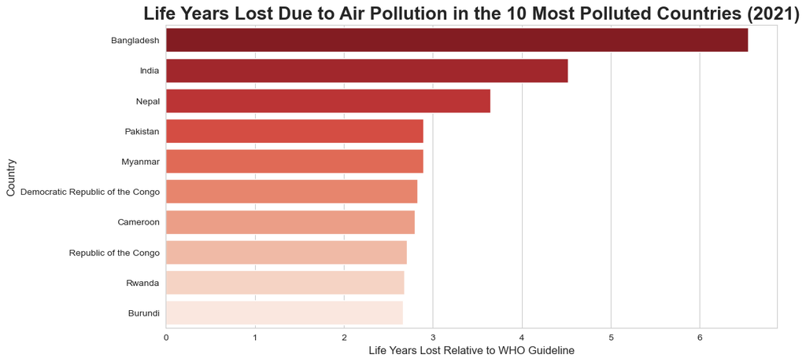

```python
sns.set_style("whitegrid")

plt.figure(figsize=(12, 6))

ax = sns.barplot(x=most_polluted2021["llpp_who_2021"], y=most_polluted2021.index, palette="Reds_r")

plt.xlabel("Life Years Lost Relative to WHO Guideline", fontsize=12)
plt.ylabel("Country", fontsize=12)
plt.title("Life Years Lost Due to Air Pollution in the 10 Most Polluted Countries (2021)", fontsize=20, fontweight="bold")

plt.savefig("Life_Years_Lost_Pollution_2021.png", dpi=300, bbox_inches="tight")

plt.show()
```

```python
most_polluted2021.index.to_list()
```

```
['Bangladesh',
 'India',
 'Nepal',
 'Pakistan',
 'Myanmar',
 'Democratic Republic of the Congo',
 'Cameroon',
 'Republic of the Congo',
 'Rwanda',
 'Burundi']
```

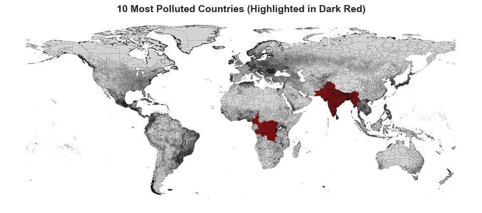

```python
most_polluted = most_polluted2021.index.to_list()

# Create a column for coloring
world["color"] = world["name0"].apply(lambda x: "#8B0000" if x in most_polluted else "#D3D3D3")

# Plot the map
fig, ax = plt.subplots(figsize=(12, 8))
world.plot(ax=ax, color = world["color"], edgecolor = "black", linewidth = 0.1)

ax.axis("off")

plt.title("10 Most Polluted Countries (Highlighted in Dark Red)", fontsize=14, fontweight="bold")

plt.savefig("Most_Polluted_Countries_Map.png", dpi=300, bbox_inches="tight")

plt.show()
```

#### 2.2 Create a potential gain in life expectancy (relative to the WHO guideline) map of eastern v/s western europe at GADM level 2 and save it as a high quality PDF.

- Plot should be in AQLI “Potential gain in life expectancy” color scale. Visit AQLI website Index page > See legend for “Potential gain in life expectancy” and infer “exact” colors from that.
- You can define east and west europe based on any acceptable definition online, but whatever definition you use - mention the source.
- Feel free to add annotations/text boxes etc. to help explain the visualization.

```python
country_df['llpp_who_2021']
```

```
country
Afghanistan              1.201555
Akrotiri and Dhekelia    0.625000
Albania                  0.832703
Algeria                  0.100864
American Samoa           0.000000
                           ...
Western Sahara           0.020000
Yemen                    0.981867
Zambia                   1.394957
Zimbabwe                 0.907912
Åland                    0.000000
Name: llpp_who_2021, Length: 252, dtype: float64
```

```python
# Merge GADM boundaries with air quality dataset
world = world.merge(data, left_on="name2", right_on="name_2", how="left")
```

```python
country_df['country_name'] = country_df.index
country_df.head()
```

| country | pm1998 | pm1999 | pm2000 | pm2001 | pm2002 | pm2003 | pm2004 | pm2005 | pm2006 | pm2007 | ... | llpp_nat_2013 | llpp_nat_2014 | llpp_nat_2015 | llpp_nat_2016 | llpp_nat_2017 | llpp_nat_2018 | llpp_nat_2019 | llpp_nat_2020 | llpp_nat_2021 | country_name |
| --- | --- | --- | --- | --- | --- | --- | --- | --- | --- | --- | --- | --- | --- | --- | --- | --- | --- | --- | --- | --- | --- |
| Afghanistan | 11.248537 | 11.091098 | 12.235030 | 14.414421 | 14.022287 | 14.296860 | 13.011372 | 14.478384 | 15.003018 | 14.327500 | ... | 0.000000 | 0.0 | 0.000640 | 0.000518 | 0.0 | 0.0 | 0.001921 | 0.00689 | 0.005976 | Afghanistan |
| Akrotiri and Dhekelia | 11.580000 | 11.515000 | 13.825000 | 12.780000 | 11.060000 | 11.535000 | 10.825000 | 12.025000 | 11.975000 | 12.200000 | ... | NaN | NaN | NaN | NaN | NaN | NaN | NaN | NaN | NaN | Akrotiri and Dhekelia |
| Albania | 16.865405 | 15.637297 | 17.362703 | 16.527027 | 18.489189 | 20.197568 | 15.982432 | 17.530811 | 19.736216 | 18.438378 | ... | 0.001351 | 0.0 | 0.013514 | 0.000000 | 0.0 | 0.0 | 0.000000 | 0.00000 | 0.000000 | Albania |
| Algeria | 6.059541 | 5.463989 | 5.864375 | 5.940199 | 5.941509 | 7.432633 | 5.375279 | 6.820259 | 6.813165 | 6.579468 | ... | NaN | NaN | NaN | NaN | NaN | NaN | NaN | NaN | NaN | Algeria |
| American Samoa | 0.767500 | 0.925625 | 1.181250 | 1.099375 | 1.250000 | 1.295625 | 1.022500 | 1.501250 | 1.310625 | 1.314375 | ... | NaN | NaN | NaN | NaN | NaN | NaN | NaN | NaN | NaN | American Samoa |

5 rows × 73 columns

```python
world_countries['country_name'] = world_countries.index

world_countries.head()
```

| name0 | geometry | obidgadm2 | name1 | name2 | country_name |
| --- | --- | --- | --- | --- | --- |
| Afghanistan | MULTIPOLYGON (((63.61554 29.46970, 63.61425 29... | 1 | Badakhshan | Baharak | Afghanistan |
| Akrotiri and Dhekelia | MULTIPOLYGON (((33.00867 34.63230, 33.00764 34... | 329 | Akrotiri | None | Akrotiri and Dhekelia |
| Albania | MULTIPOLYGON (((19.84179 40.04882, 19.83501 40... | 344 | Berat | Beratit | Albania |
| Algeria | MULTIPOLYGON (((1.32778 20.73215, 1.31754 20.7... | 381 | Adrar | Adrar | Algeria |
| American Samoa | MULTIPOLYGON (((-170.76183 -14.36973, -170.762... | 1885 | Eastern | Ituau | American Samoa |

```python
# Merge GADM country boundaries with air quality dataset
world_countries = world_countries.merge(country_df, left_on="country_name", right_on="country_name", how="left")
```

```python
world_countries["llpp_who_2021"] # PGLE is same as life years lost due to non-compliance
```

```
0      1.201555
1      0.625000
2      0.832703
3      0.100864
4      0.000000
         ...
247    0.020000
248    0.981867
249    1.394957
250    0.907912
251    0.000000
Name: llpp_who_2021, Length: 252, dtype: float64
```

```python
# Eastern vs. Western Europe based on UN Statistics Division
## Source - https://unstats.un.org/unsd/methodology/m49/
eastern_europe = ["Belarus", "Bulgaria", "Czechia", "Hungary", "Poland", "Republic of Moldova",
                  "Romania", "Russian Federation", "Slovakia", "Ukraine"]
western_europe = ["Austria", "Belgium", "France", "Germany", "Liechtenstein", "Luxembourg",
                  "Monaco", "Netherlands", "Switzerland"]

# Assign region labels
world_countries["EU_Region"] = np.where(world_countries["country_name"].isin(eastern_europe), "Eastern Europe",
                         np.where(world_countries["country_name"].isin(western_europe), "Western Europe", "Other"))

world_countries.head(2)
```

|  | geometry | obidgadm2 | name1 | name2 | country_name | pm1998 | pm1999 | pm2000 | pm2001 | pm2002 | ... | llpp_nat_2013 | llpp_nat_2014 | llpp_nat_2015 | llpp_nat_2016 | llpp_nat_2017 | llpp_nat_2018 | llpp_nat_2019 | llpp_nat_2020 | llpp_nat_2021 | EU_Region |
| --- | --- | --- | --- | --- | --- | --- | --- | --- | --- | --- | --- | --- | --- | --- | --- | --- | --- | --- | --- | --- | --- |
| 0 | MULTIPOLYGON (((63.61554 29.46970, 63.61425 29... | 1 | Badakhshan | Baharak | Afghanistan | 11.248537 | 11.091098 | 12.23503 | 14.414421 | 14.022287 | ... | 0.0 | 0.0 | 0.00064 | 0.000518 | 0.0 | 0.0 | 0.001921 | 0.00689 | 0.005976 | Other |
| 1 | MULTIPOLYGON (((33.00867 34.63230, 33.00764 34... | 329 | Akrotiri | None | Akrotiri and Dhekelia | 11.580000 | 11.515000 | 13.82500 | 12.780000 | 11.060000 | ... | NaN | NaN | NaN | NaN | NaN | NaN | NaN | NaN | NaN | Other |

2 rows × 78 columns

```python
# Eastern vs. Western Europe based on UN Statistics Division
## Source - https://unstats.un.org/unsd/methodology/m49/
eastern_europe = ["Belarus", "Bulgaria", "Czechia", "Hungary", "Poland", "Republic of Moldova",
                  "Romania", "Russian Federation", "Slovakia", "Ukraine"]
western_europe = ["Austria", "Belgium", "France", "Germany", "Liechtenstein", "Luxembourg",
                  "Monaco", "Netherlands", "Switzerland"]

# Assign region labels
world["EU_Region"] = np.where(world["name0"].isin(eastern_europe), "Eastern Europe",
                         np.where(world["name0"].isin(western_europe), "Western Europe", "Other"))

world.head(2)
```

|  | obidgadm2 | name0 | name1 | name2 | geometry | objectid_gadm2 | iso_alpha3 | country | name_1 | name_2 | ... | llpp_nat_2013 | llpp_nat_2014 | llpp_nat_2015 | llpp_nat_2016 | llpp_nat_2017 | llpp_nat_2018 | llpp_nat_2019 | llpp_nat_2020 | llpp_nat_2021 | EU_Region |
| --- | --- | --- | --- | --- | --- | --- | --- | --- | --- | --- | --- | --- | --- | --- | --- | --- | --- | --- | --- | --- | --- |
| 0 | 1 | Afghanistan | Badakhshan | Baharak | POLYGON ((71.41149 36.55717, 71.40954 36.55237... | 1.0 | AFG | Afghanistan | Badakhshan | Baharak | ... | 0.0 | 0.0 | 0.0 | 0.0 | 0.0 | 0.0 | 0.0 | 0.0 | 0.0 | Other |
| 1 | 2 | Afghanistan | Badakhshan | Darwaz | POLYGON ((71.27620 38.00465, 71.27578 38.00471... | 2.0 | AFG | Afghanistan | Badakhshan | Darwaz | ... | 0.0 | 0.0 | 0.0 | 0.0 | 0.0 | 0.0 | 0.0 | 0.0 | 0.0 | Other |

2 rows × 86 columns

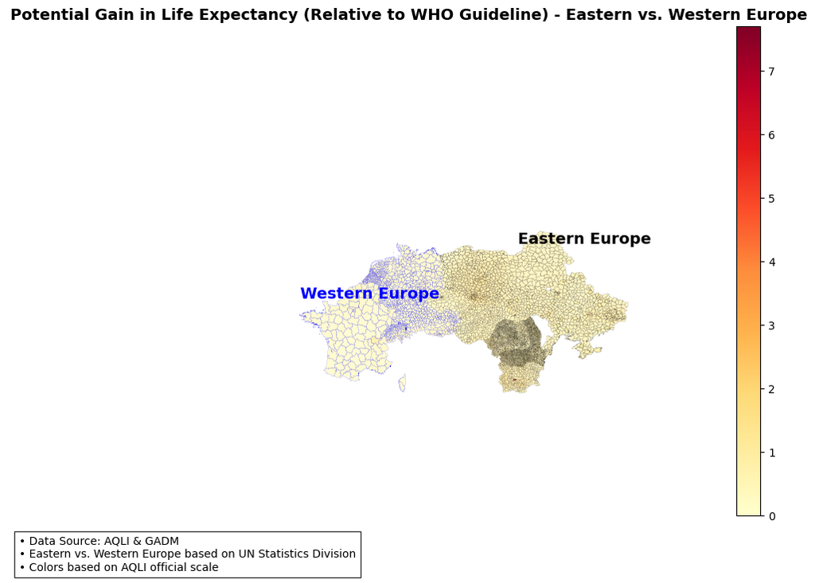

```python
# Plot using 'YlOrRd' colormap
fig, ax = plt.subplots(figsize=(12, 8))

# Get min & max PGLE values for Eastern & Western Europe
min_llpp_who_2021 = world[world["EU_Region"].isin(["Eastern Europe", "Western Europe"])]["llpp_who_2021"].min()
max_llpp_who_2021 = world[world["EU_Region"].isin(["Eastern Europe", "Western Europe"])]["llpp_who_2021"].max()

world[world["EU_Region"] == "Eastern Europe"].plot(column="llpp_who_2021", cmap="YlOrRd",
                                            edgecolor="black", linewidth=0.1, alpha=0.7, ax=ax, vmin=min_llpp_who_2021, vmax=max_llpp_who_2021, legend=True)

world[world["EU_Region"] == "Western Europe"].plot(column="llpp_who_2021", cmap="YlOrRd",
                                            edgecolor="blue", linewidth=0.1, alpha=0.7, ax=ax, vmin=min_llpp_who_2021, vmax=max_llpp_who_2021,  legend=False)

ax.axis("off")
ax.set_xlim(-30, 50)  # Longitude range for Europe
ax.set_ylim(30, 75)   # Latitude range for Europe

plt.title("Potential Gain in Life Expectancy (Relative to WHO Guideline) - Eastern vs. Western Europe", fontsize=14, fontweight="bold")

# Add a text box explaining the visualization
plt.annotate("Eastern Europe", xy=(25, 55), xycoords='data', fontsize=14, color="black", fontweight="bold")
plt.annotate("Western Europe", xy=(-5, 50), xycoords='data', fontsize=14, color="blue", fontweight="bold")

textstr = "• Data Source: AQLI & GADM\n• Eastern vs. Western Europe based on UN Statistics Division\n• Colors based on AQLI official scale"
plt.annotate(textstr, xy=(0.02, 0.02), xycoords="figure fraction", fontsize=10, color="black", bbox=dict(facecolor="white", alpha=0.8))

# Save as high-quality PDF
plt.savefig("Potential_Gain_Life_Expectancy_EW_Europe.pdf", dpi=600, bbox_inches="tight", format="pdf")

plt.show()
```

#### 2.3 Look at the AQLI website > switch to Air pollution tab > plot a static version of the global pollution map you see there, in those “exact” same colors. Export it as a high quality (320 dpi) SVG file.

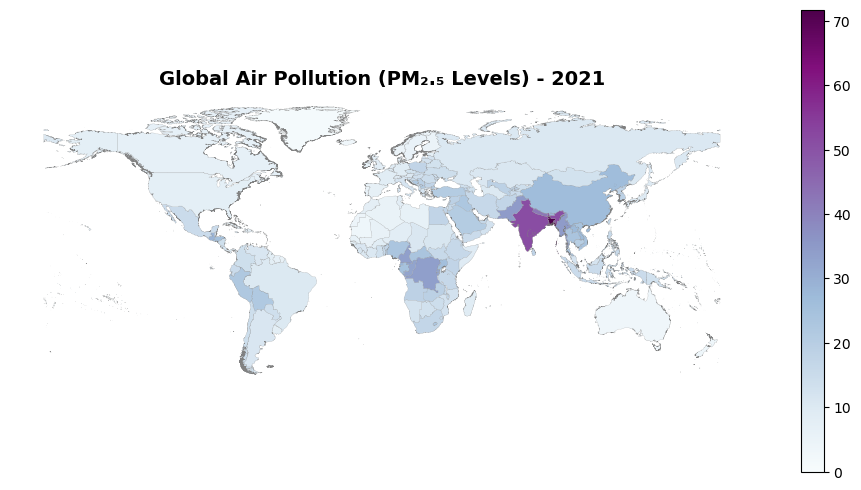

```python
fig, ax = plt.subplots(figsize=(12, 6))
world_countries.plot(column="pm2021", cmap='BuPu', linewidth=0.1, edgecolor="gray", legend=True, ax=ax)

ax.axis("off")

plt.title("Global Air Pollution (PM₂.₅ Levels) - 2021", fontsize=14, fontweight="bold")

plt.savefig("AQLI_Global_PM25_Map.svg", dpi=320, format="svg", bbox_inches="tight")

plt.show()
```

### 4. Verbal reasoning and writing

#### Key Takeaways from AQLI Annual Update 2024

- The most polluted regions have air six times dirtier than the cleanest ones, cutting 2.7 years more from life expectancy in these areas.
- While 94 countries (81% of the world’s population) have PM2.5 air quality standards, weak enforcement often prevents meaningful pollution reduction.
- If all regions met their own air quality standards, the world would gain 3 billion life-years, with Iraq, Bangladesh, and Pakistan seeing nearly 2 years of added life expectancy.

### Thank You

'************************************************************'